# Describe variables

Simon Chen

10/26/2021

Describe the variables you are interested in working with – there should be around 5, at least one numeric and at least one factor, but a few more is fine. The descriptions should include information on the data type for each variable (numeric or factor), the range of values, and some type of tabular or graphical summary (crosstabs, histogram, boxplot, scatterplot, etc.).

## Variables

1. Study Class :  
   Describes top-level classification of the study as: Psychotherapy, Pharmacotherapy, CIH, Nonpharm biologic, Nonpharm cognitive, Collaborative Care, Psychotherapy & Pharmacotherapy, Psychotherapy & CIH, Other Mixed.  
   I will try to measure the effectiveness of each treatment method
2. Total N Randomized :  
   Total participants randomized in the study (total of all arms). The range is [8, 943], we can see the distribution in different study class.

```r
library(tidyverse)
# Import the data
dat <- read.csv('PTSD_Outcomes_Within_Each_Treatment_Arm.csv')
dat <- tibble(dat)
dat
```

```
## # A tibble: 3,737 × 77
##    study_id     Study.Class  Treatment.Focus.… Total.N.Randomi… Intervention.Gr…
##    <chr>        <chr>        <chr>                        <int> <chr>
##  1 acarturk201… Psychothera… PTSD                            98 A
##  2 acarturk201… Psychothera… PTSD                            98 A
##  3 acarturk201… Psychothera… PTSD                            98 A
##  4 acarturk201… Psychothera… PTSD                            98 B
##  5 acarturk201… Psychothera… PTSD                            98 B
##  6 acarturk201… Psychothera… PTSD                            98 B
##  7 acarturk201… Psychothera… PTSD                            98 A
##  8 acarturk201… Psychothera… PTSD                            98 A
##  9 acarturk201… Psychothera… PTSD                            98 A
## 10 acarturk201… Psychothera… PTSD                            98 B
## # … with 3,727 more rows, and 72 more variables:
## #   Treatment.Focus..Arm.level. <chr>,
## #   Treatment.Focus.Subclass..Arm.level. <chr>,
## #   N.Completed.Outcome.Measurement <int>,
## #   N.Completed.Outcome.Measurement.Detail <chr>,
## #   Publication.Treatment.Name <chr>, NCPTSD.Treatment.Name <chr>,
## #   Psychotherapy <chr>, Psychotherapy.Subclass <chr>, Pharmacotherapy <chr>, …
```

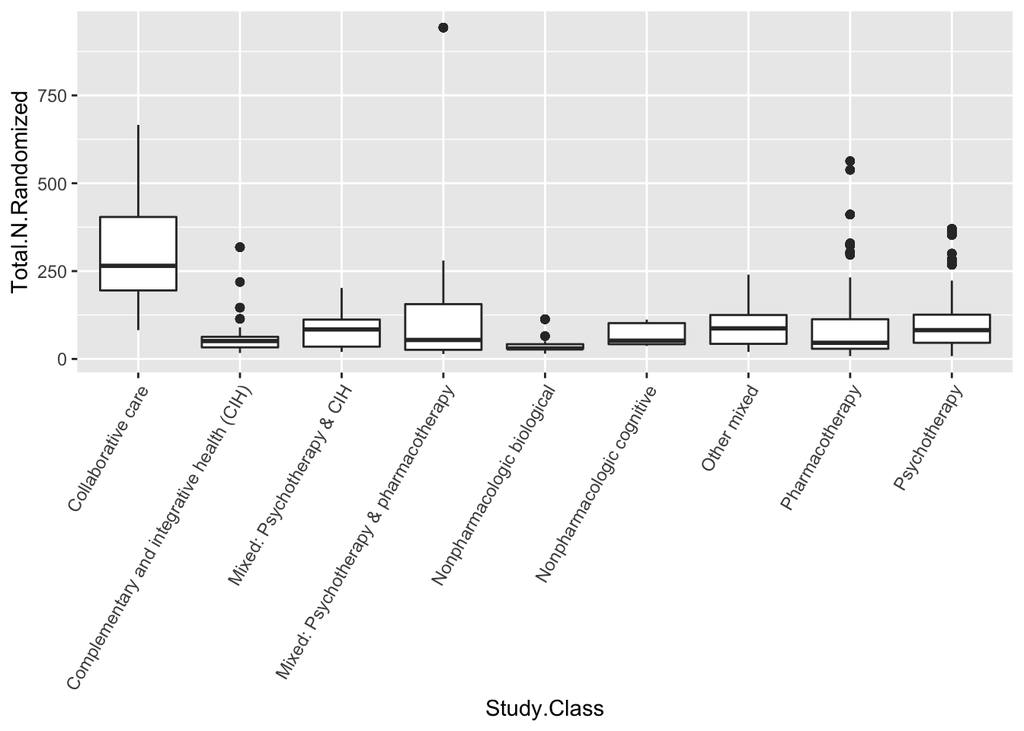

```r
ggplot(data = dat, aes(x = Study.Class, y = Total.N.Randomized)) +
  geom_boxplot() +
  theme(axis.text.x = element_text(angle = 60, hjust = 1))
```

3. Mean Measure Score :  
   Mean measure score for PTSD outcome To show the outcome performance. [-2.5, 129.31]

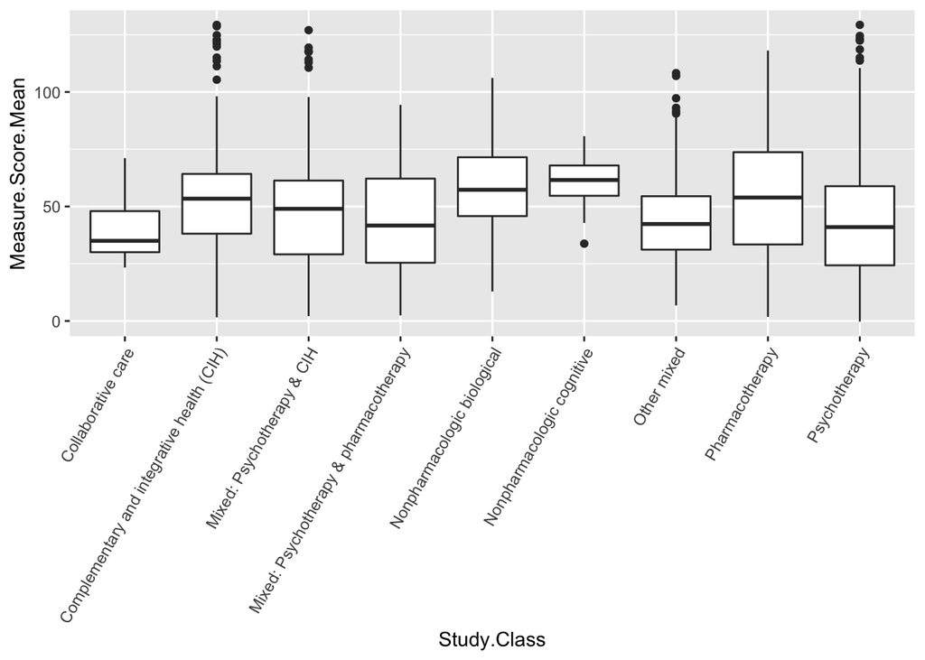

```r
ggplot(data = dat, aes(x = Study.Class, y = Measure.Score.Mean)) +
  geom_boxplot() +
  theme(axis.text.x = element_text(angle = 60, hjust = 1))
```

4. Psychotherapy :  
   Categorization of the arm/intervention: Yes, No, or null for Psychotherapy This is one of the specific treatment type which is a factor of effectiveness of the whole therapy.
5. Male/Female percent :  
   At the study level, percent male/female. Because I think this would be different effect on sex. [0, 1]